# 03 - Additional Plot Types

### **Binning data**

When the data on the x axis is a continuous value, it can be useful to break it into different bins in order to get a better visualization of the changes in the data.

For this exercise, we will look at the relationship between tuition and the Undergraduate population abbreviated as `UG` in this data. We will start by looking at a scatter plot of the data and examining the impact of different bin sizes on the visualization.

**Instructions**

- Create a `regplot` of `Tuition` and `UG` and set the `fit_reg` parameter to `False` to disable the regression line.
- Create another plot with the `UG` data divided into 5 bins.
- Create a `regplot()` with the data divided into 8 bins.

```python
reticulate::repl_python()
```

```
Python 3.6.11 (/home/cla/.local/share/r-miniconda/envs/r-reticulate/bin/python)
Reticulate 1.18 REPL -- A Python interpreter in R.
```

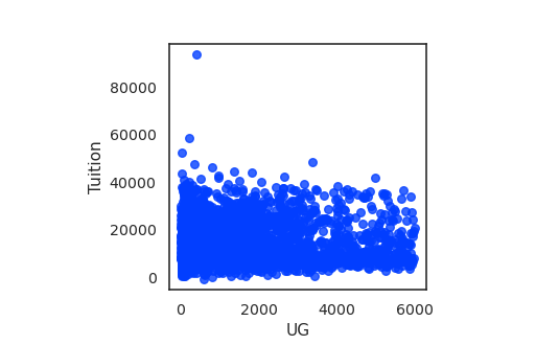

```python
# Create a scatter plot by disabling the regression line
_ = sns.regplot(data = df2,
            y = df2[df2['UG'] <= 6000]['Tuition'],
            x = df2[df2['UG'] <= 6000]["UG"],
            fit_reg = False)

plt.show()
```

```python
plt.clf()
```

```python
reticulate::repl_python()
```

```
Python 3.6.11 (/home/cla/.local/share/r-miniconda/envs/r-reticulate/bin/python)
Reticulate 1.18 REPL -- A Python interpreter in R.
```

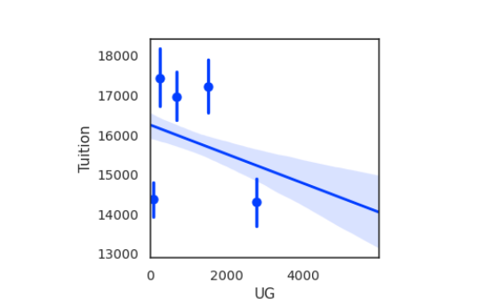

```python
# Create a scatter plot and bin the data into 5 bins
_ = sns.regplot(data = df2,
            y = df2[df2['UG'] <= 6000]['Tuition'],
            x = df2[df2['UG'] <= 6000]["UG"],
            x_bins = 5)

plt.show()
```

```python
plt.clf()
```

```python
reticulate::repl_python()
```

```
Python 3.6.11 (/home/cla/.local/share/r-miniconda/envs/r-reticulate/bin/python)
Reticulate 1.18 REPL -- A Python interpreter in R.
```

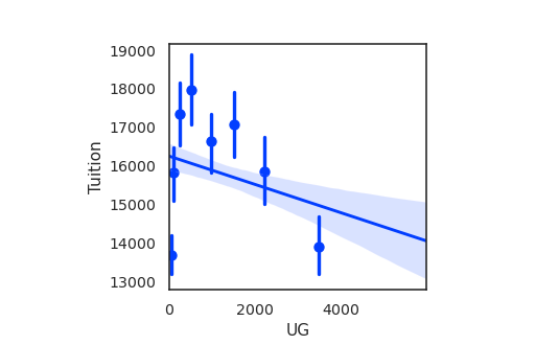

```python
# Create a regplot and bin the data into 8 bins
_ = sns.regplot(data = df2,
            y = df2[df2['UG'] <= 6000]['Tuition'],
            x = df2[df2['UG'] <= 6000]["UG"],
            x_bins = 8)

plt.show()
```

```python
plt.clf()
```

## **Matrix plots**

**1. Matrix Plots**

The final category of plots we will discuss in this section are matrix plots. The heatmap is the most common type of matrix plot and can be easily created by Seaborn. These types of matrix plots can be useful for quickly seeing trends in a dataset. Let’s learn how to construct these plots in Seaborn and use them to look at our bicycle rental data.

**2. Getting data in the right format**

Seaborn’s heatmap() function expects the data to be in a matrix. To illustrate this process, we can look at the bicycle data to see how rentals vary by day of the week and month. The crosstab() function builds a table to summarize the data by the day and month. In this example, we also use the aggfunc argument to get the average number of rentals for each of the day and month combinations. This is a very useful capability available in pandas and makes it easy to plot a heatmap once it is in this format.

```python
reticulate::repl_python()
```

```
Python 3.6.11 (/home/cla/.local/share/r-miniconda/envs/r-reticulate/bin/python)
Reticulate 1.18 REPL -- A Python interpreter in R.
```

```python
pd.crosstab(df3['mnth'], df3['weekday'], values = df3['total_rentals'], aggfunc = 'mean').round(0)
```

```
weekday       1       2       3       4       5       6
mnth
1           NaN     NaN     NaN   918.0  3456.0   959.0
2        1913.0     NaN     NaN  3830.0     NaN     NaN
3        6153.0  5847.0  2134.0  2304.0     NaN     NaN
4           NaN     NaN  3944.0  6457.0     NaN  4856.0
5           NaN  5028.0  4717.0  5817.0     NaN     NaN
6        4515.0     NaN     NaN  4968.0  4586.0  5299.0
7           NaN     NaN  4656.0  3784.0     NaN     NaN
8        4326.0  4602.0  7697.0     NaN  4153.0     NaN
9           NaN     NaN  5331.0  5115.0     NaN     NaN
10          NaN     NaN     NaN  7570.0  8156.0     NaN
11       5152.0     NaN  3613.0     NaN  4779.0  5629.0
12          NaN  1162.0     NaN     NaN  3577.0  3190.0
```

**3. Build a heatmap**

```python
reticulate::repl_python()
```

```
Python 3.6.11 (/home/cla/.local/share/r-miniconda/envs/r-reticulate/bin/python)
Reticulate 1.18 REPL -- A Python interpreter in R.
```

```python
fig, ax = plt.subplots()
_ = fig.tight_laytout(pad = 5)
```

[output not shown]

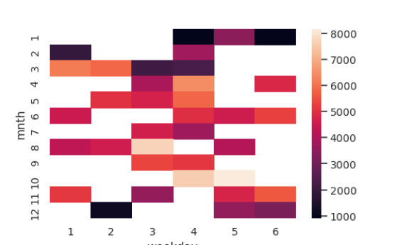

```python
_ = sns.heatmap(pd.crosstab(df3['mnth'], df3['weekday'], values = df3['total_rentals'], aggfunc = 'mean'))
plt.show()
```

```python
plt.clf()
```

**4. Customize a heatmap**

```python
reticulate::repl_python()
```

```
Python 3.6.11 (/home/cla/.local/share/r-miniconda/envs/r-reticulate/bin/python)
Reticulate 1.18 REPL -- A Python interpreter in R.
```

```python
df_crosstab = pd.crosstab(df3['mnth'], df3['weekday'], values = df3['total_rentals'], aggfunc = 'mean').round(0)

_ = sns.heatmap(df_crosstab, annot = True, fmt = "d", cmap = 'YlGnBu', cbar = False, linewidth = 0.5)
```

```
ValueError: Unknown format code 'd' for object of type 'float'
```

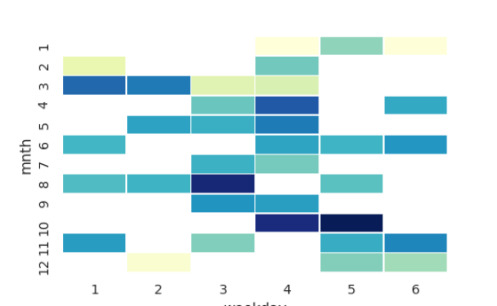

```python
?sns.heatmap
plt.show()
```

```python
plt.clf()
```

```python
reticulate::repl_python()
```

```
Python 3.6.11 (/home/cla/.local/share/r-miniconda/envs/r-reticulate/bin/python)
Reticulate 1.18 REPL -- A Python interpreter in R.
```

```python
df_crosstab = pd.crosstab(df3['mnth'], df3['weekday'], values = df3['total_rentals'], aggfunc = 'mean').round(0)

_ = sns.heatmap(df_crosstab, annot = True, fmt = "d", cmap = 'YlGnBu', cbar = True)
```

```
ValueError: Unknown format code 'd' for object of type 'float'
```

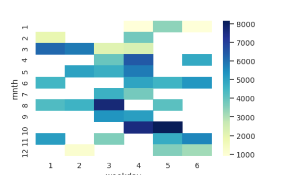

```python
plt.show()
```

```python
plt.clf()
```

**6. Plotting a correlation matrix**

```python
reticulate::repl_python()
```

```
Python 3.6.11 (/home/cla/.local/share/r-miniconda/envs/r-reticulate/bin/python)
Reticulate 1.18 REPL -- A Python interpreter in R.
```

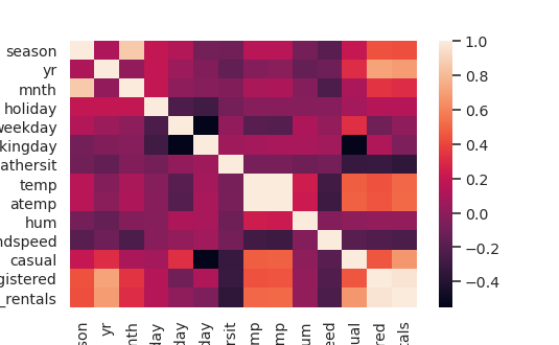

```python
_ = sns.heatmap(df3.corr())
plt.show()
```

```python
plt.clf()
```

**7. Let’s practice!**

It’s time to put this into practice.

### **Creating heatmaps**

A heatmap is a common matrix plot that can be used to graphically summarize the relationship between two variables. For this exercise, we will start by looking at guests of the Daily Show from 1999 - 2015 and see how the occupations of the guests have changed over time.

The data includes the date of each guest appearance as well as their occupation. For the first exercise, we need to get the data into the right format for Seaborn’s `heatmap` function to correctly plot the data. All of the data has already been read into the `df` variable.

**Instructions**

- Use pandas’ `crosstab()` function to build a table of visits by `Group` and `Year`.
- Print the `pd_crosstab` DataFrame.
- Plot the data using Seaborn’s `heatmap()`.

```python
reticulate::repl_python()
```

```
Python 3.6.11 (/home/cla/.local/share/r-miniconda/envs/r-reticulate/bin/python)
Reticulate 1.18 REPL -- A Python interpreter in R.
```

```python
# Create a crosstab table of the data
pd_crosstab = pd.crosstab(df4["Group"], df4["YEAR"])
print(pd_crosstab)
```

```
YEAR            1999  2000  2001  2002  2003  ...  2011  2012  2013  2014  2015
Group                                         ...
Academic           0     0     2     0     4  ...    10     8     8    10     2
Acting           108   100    92    84    74  ...    42    33    60    47    33
Advocacy           0     1     0     1     0  ...     1     2     2     3     3
Athletics          0     3     1     2     0  ...     2     7     4     4     3
Business           0     1     0     0     0  ...     3     3     3     1     1
Clergy             0     0     0     1     1  ...     1     2     0     0     0
Comedy            25    12    11     5    12  ...     7     6     6     9     7
Consultant         0     0     0     0     1  ...     0     0     0     0     0
Government         0     0     2     1     2  ...     3     3     7     6     0
Media             11    21    31    42    41  ...    51    52    51    53    24
Military           0     0     0     0     0  ...     3     1     1     1     1
Misc               0     0     2     1     1  ...     5     6     2     5     3
Musician          17    13    11    10     7  ...     6     5     5     8     5
Political Aide     0     1     1     2     1  ...     1     1     3     2     3
Politician         2    13     3     8    14  ...    23    29    11    13    14
Science            0     0     0     0     1  ...     5     2     2     1     1

[16 rows x 17 columns]
```

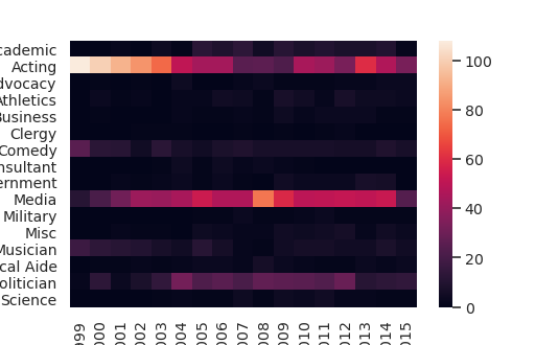

```python
# Plot a heatmap of the table
_ = sns.heatmap(pd_crosstab)

# Rotate tick marks for visibility
_ = plt.yticks(rotation=0)
_ = plt.xticks(rotation=90)

plt.show()
```

```python
plt.clf()
```

### **Customizing heatmaps**

Seaborn supports several types of additional customizations to improve the output of a heatmap. For this exercise, we will continue to use the Daily Show data that is stored in the `df` variable but we will customize the output.

**Instructions**

- Create a crosstab table of `Group` and `YEAR`
- Create a heatmap of the data using the `BuGn` palette
- Disable the `cbar` and increase the `linewidth` to 0.3

```python
reticulate::repl_python()
```

```
Python 3.6.11 (/home/cla/.local/share/r-miniconda/envs/r-reticulate/bin/python)
Reticulate 1.18 REPL -- A Python interpreter in R.
```

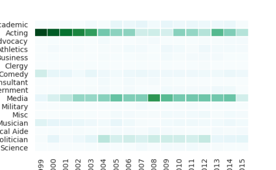

```python
# Create the crosstab DataFrame
pd_crosstab = pd.crosstab(df4["Group"], df4["YEAR"])

# Plot a heatmap of the table with no color bar and using the BuGn palette
_ = sns.heatmap(pd_crosstab, cbar = False, cmap = "BuGn", linewidths = 0.3)

# Rotate tick marks for visibility
_ = plt.yticks(rotation = 0)
_ = plt.xticks(rotation = 90)

#Show the plot
plt.show()
```

```python
plt.clf()
```